# Parallelization with NIMBLE

### Overview

Parallelization is a useful feature of multi-core processors that improves computation time by running multiple independent processes simultaneously.

Due to how NIMBLE builds models and algorithms and automatically generates C++ code, parallelizating NIMBLE code requires some care. Naive approaches such as building a single model using standard parallelization packages in R to parallelize an MCMC are likely to fail, or worse, behave incorrectly without failing.

That said, parallelizing NIMBLE pipelines is possible and can be very convenient if done properly. The key consideration is to ensure that all NIMBLE execution, including model building, is conducted inside the parallelized code. This ensures that all models and algorithms are independent objects that don’t interfere with each other.

Note that we have work in progress to make parallelizing NIMBLE code easier and more powerful.

### Parallelization in practice

In this example, we’ll use basic functionality from the `parallel` package to run MCMC in parallel chains.

Here we lay out how to do the steps manually. The [function `nimbleParallelMCMC` (available here)](https://github.com/nimble-dev/nimble-demos/blob/master/parallelization/parallelMCMC.R) provides a wrapper function to do this easily in one function call.

```r
library(parallel)
```

First we create a cluster, specifying the number of cores we want the cluster to operate across.

```r
this_cluster <- makeCluster(4)
```

(Side note: do not use `makeForkCluster` when parallelizing NIMBLE code; it will not work. `makeCluster` sets up a PSOCK cluster, which will work. If you really want to use forking, if you are able to set up separate directories for NIMBLE’s generated code for each worker, that should allow one to use forked processes. One option is to use `unixtools::set.tempdir()` and another is to use the `dirName` argument to `compileNimble()`.)

We’ll set up a situation where we run four independent MCMC simulations. As part of this, we’ll also calculate WAIC, a model selection tool, from the combined chains. Note that calculating WAIC in this way only allows calculation of the default conditional WAIC and requires that all parent nodes of data nodes be monitored, as discussed further in `help(calculateWAIC)`.

The key is to create a function that includes all the modeling steps and run that function in parallel. Note that `myCode` could have been created outside the parallelized code, but all the other steps need to be done inside the parallelized code.

```r
set.seed(10120)

useWAIC <- TRUE

# Simulate some data
myData <- rgamma(1000, shape = 0.4, rate = 0.8)

library(nimble)
myCode <- nimbleCode({
  a ~ dunif(0, 100)
  b ~ dnorm(0, 100)

  for (i in 1:length_y) {
    y[i] ~ dgamma(shape = a, rate = b)
  }
})

# Create a function with all the needed code
run_MCMC_allcode <- function(seed, data, code, useWAIC = TRUE) {
  library(nimble)

  myModel <- nimbleModel(code = code,
                          data = list(y = data),
                          constants = list(length_y = 1000),
                          inits = list(a = 0.5, b = 0.5))

  CmyModel <- compileNimble(myModel)

  if(useWAIC)
    monitors <- myModel$getParents(myModel$getNodeNames(dataOnly = TRUE), stochOnly = TRUE)
  ## One may also wish to add additional monitors

  myMCMC <- buildMCMC(CmyModel, monitors = monitors)
  CmyMCMC <- compileNimble(myMCMC)

  results <- runMCMC(CmyMCMC, niter = 10000, setSeed = seed)

  return(results)
}
```

Now, we execute the desired code using `parLapply`, which is equivalent to `lapply` with each process running in parallel.

```r
chain_output <- parLapply(cl = this_cluster, X = 1:4,
                          fun = run_MCMC_allcode,
                          data = myData, code = myCode,
                          useWAIC = useWAIC)

# It's good practice to close the cluster when you're done with it.
stopCluster(this_cluster)
```

Alternatively, we could use `foreach` with the *doParallel* backend (via `registerDoParallel`, which uses `makeCluster` by default under the hood) to invoke `run_MCMC_allcode` in parallel.

We ran four independent MCMCs.

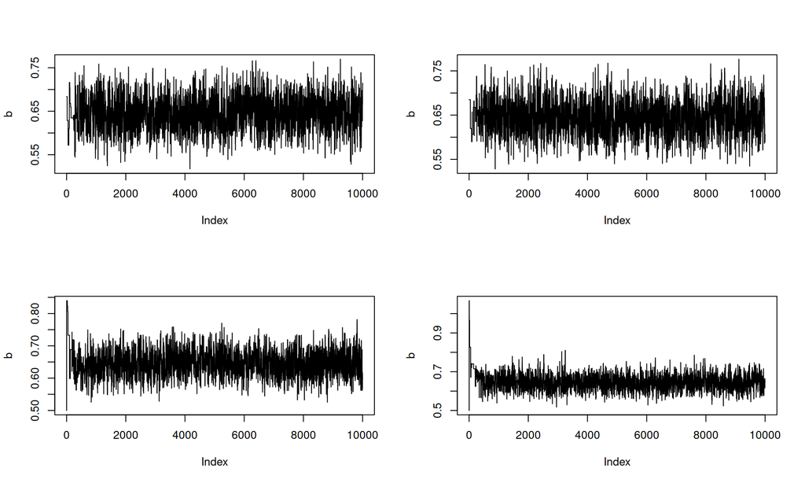

```r
par(mfrow = c(2,2))
for (i in 1:4) {
  this_output <- chain_output[[i]]
  plot(this_output[,"b"], type = "l", ylab = 'b')
}
```